# BirdsOfPreyProject

James Scudder

2023-07-25

# Bird of Prey Persecution

The original dataset can be found here: [RSPB](https://opendata-rspb.opendata.arcgis.com/datasets/RSPB::confirmed-raptor-persecution-incidents-public/explore)

The data are collated by the RSPB Investigations Team, a specialist unit set up to assist the statutory agencies with the investigation and prosecution of crimes against wild birds. These data are the most complete centralised set of known confirmed raptor persecution incident data for the UK, and has been recorded consistently for several decades. Only the highest evidentially weighted incidents – those classified as ‘confirmed,’ are included here.

‘Confirmed’ incidents are those were circumstances indicate that an illegal act has taken place. These incidents are typically substantiated by evidence such as post-mortem or toxicological analysis, or reliable eyewitness evidence.

These figures represent only those incidents known to RSPB: many remain undetected and unreported, particularly those that occur in remote areas. Population studies and scientific reports therefore provide essential bigger picture information on the conservation impact of persecution for a number of raptor species.

*Link to RSPB report on presecution of birds of prey uk:* [RSPB](https://www.rspb.org.uk/about-the-rspb/about-us/media-centre/press-releases/birdcrime/)

### My personal analysis

load packages

```r
library(tidyverse)
library(here)
library(janitor)
library(RColorBrewer)
library(skimr)
library(readr)
```

#load data

```r
birds <- read_csv(here("Data", "raptors.csv"))
```

# Data exploration

```r
install.packages("skimr")
library(skimr)
skim(birds)
```

Data summary

| Name | birds |
| --- | --- |
| Number of rows | 1558 |
| Number of columns | 13 |
| _______________________ |  |
| Column type frequency: |  |
| character | 8 |
| numeric | 5 |
| ________________________ |  |
| Group variables | None |

**Variable type: character**

| skim_variable | n_missing | complete_rate | min | max | empty | n_unique | whitespace |
| --- | --- | --- | --- | --- | --- | --- | --- |
| County | 0 | 1 | 4 | 24 | 0 | 94 | 0 |
| Incident_Type | 0 | 1 | 8 | 28 | 0 | 6 | 0 |
| Month | 0 | 1 | 3 | 9 | 0 | 13 | 0 |
| Grid_Square | 0 | 1 | 3 | 4 | 0 | 744 | 0 |
| Details | 0 | 1 | 26 | 160 | 0 | 394 | 0 |
| More_Info_Here | 0 | 1 | 7 | 150 | 0 | 270 | 0 |
| Country | 0 | 1 | 5 | 16 | 0 | 4 | 0 |
| GlobalID | 0 | 1 | 38 | 38 | 0 | 1558 | 0 |

**Variable type: numeric**

| skim_variable | n_missing | complete_rate | mean | sd | p0 | p25 | p50 | p75 | p100 | hist |
| --- | --- | --- | --- | --- | --- | --- | --- | --- | --- | --- |
| OBJECTID | 0 | 1 | 7911.50 | 449.90 | 7133.00 | 7522.25 | 7911.50 | 8300.75 | 8690.00 | ▇▇▇▇▇ |
| RSPB_Reference | 0 | 1 | 96549.98 | 4118.44 | 87794.00 | 93524.25 | 96835.50 | 100192.50 | 103765.00 | ▃▆▇▇▆ |
| Year | 0 | 1 | 2013.75 | 4.40 | 2007.00 | 2010.00 | 2013.00 | 2018.00 | 2021.00 | ▇▇▇▆▇ |
| SHAPE_Length | 0 | 1 | 68236.14 | 3108.71 | 62363.53 | 65610.65 | 68138.45 | 70566.00 | 76226.14 | ▅▇▇▅▂ |
| SHAPE_Area | 0 | 1 | 291613731.67 | 26726336.20 | 243075073.70 | 269046792.20 | 290177425.00 | 311221979.80 | 363150883.70 | ▆▇▇▃▂ |

# Pipe %>% functions (cleaner code)

```r
birds <- read_csv(here("Data", "raptors.csv"))
cleanbirds <- birds %>%
  clean_names() %>%
  rename(object_id = objectid) %>%
  select(incident_type, details, county, month, year) %>%
  arrange(desc(year))
```

# Save cleanbirds as csv for future access

```r
write_csv(cleanbirds,"clean_birds.csv")
```

```r
incidents_by_county <- cleanbirds %>%
  group_by(county) %>%
  count()
```

# Display the top 10 counties with the most incidents

```r
incidents_by_county %>%
  arrange(desc(n)) %>%
  head(10)
```

```
## # A tibble: 10 × 2
## # Groups:   county [10]
##    county                    n
##    <chr>                 <int>
##  1 NORTH YORKSHIRE         184
##  2 HIGHLAND                 84
##  3 SCOTTISH BORDERS         63
##  4 NORFOLK                  57
##  5 PERTH AND KINROSS        52
##  6 SOUTH LANARKSHIRE        46
##  7 ANGUS                    45
##  8 ABERDEENSHIRE            43
##  9 DERBYSHIRE               42
## 10 DUMFRIES AND GALLOWAY    41
```

# incidents by year

```r
incidents_by_year <- cleanbirds %>%
  group_by(year) %>%
  count()

max_incidents <- incidents_by_year %>%
  arrange(desc(n)) %>%
  head(1)
```

# Most Common Incident-Type

```r
most_common_incident_type <- cleanbirds %>%
  group_by(incident_type) %>%
  count() %>%
  arrange(desc(n)) %>%
  head(10)
```

```r
view(most_common_incident_type)
```

# Most Incidents by Species

```r
incident_species <- cleanbirds %>%
  group_by(details, year) %>%
  count() %>%
  arrange(desc(year))
```

```r
view(incident_species)
```

# Visualization of the data with ggplot

# Number of Incidents Per Year

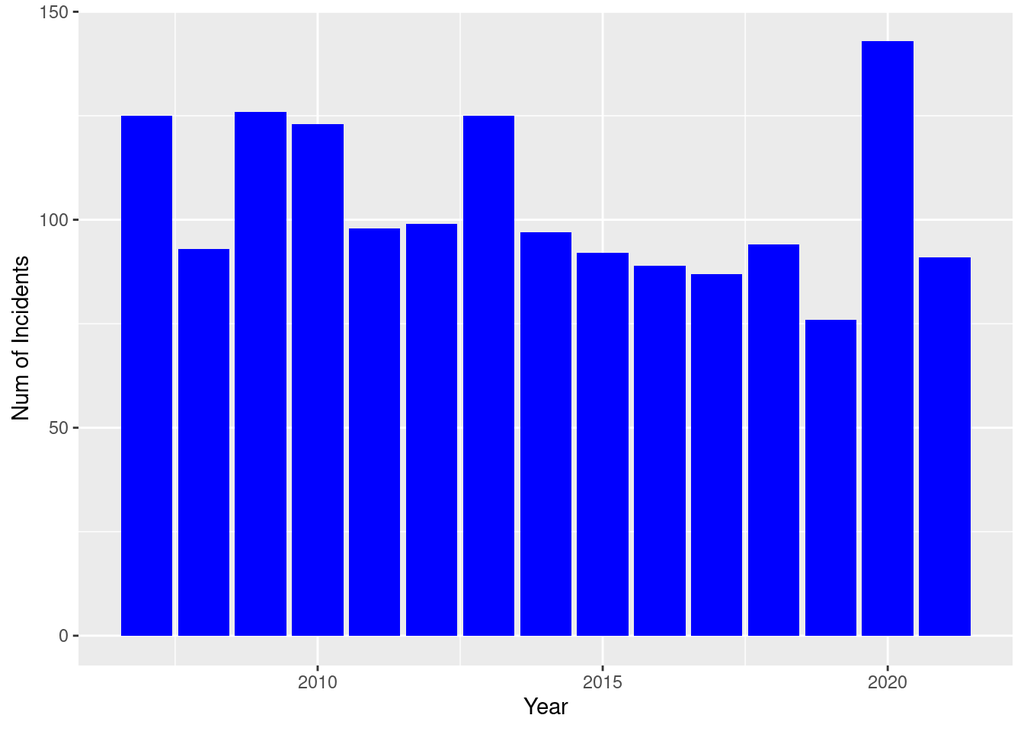

```r
ggplot(incidents_by_year, aes(x = year, y = n)) +
  geom_bar(stat = "identity", fill  = "blue") +
  xlab("Year") +
  ylab("Num of Incidents")
```

# Most Common Incident type

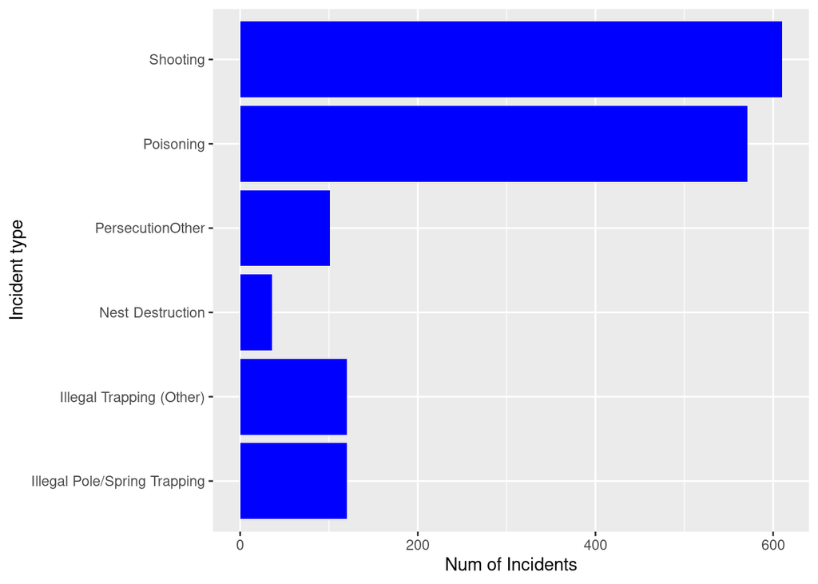

```r
ggplot(most_common_incident_type, aes(x = incident_type, y = n)) +
  geom_bar(stat = "identity", fill = "blue") +
  coord_flip() +
  xlab("Incident type") +
  ylab("Num of Incidents")
```

# Most Common Species

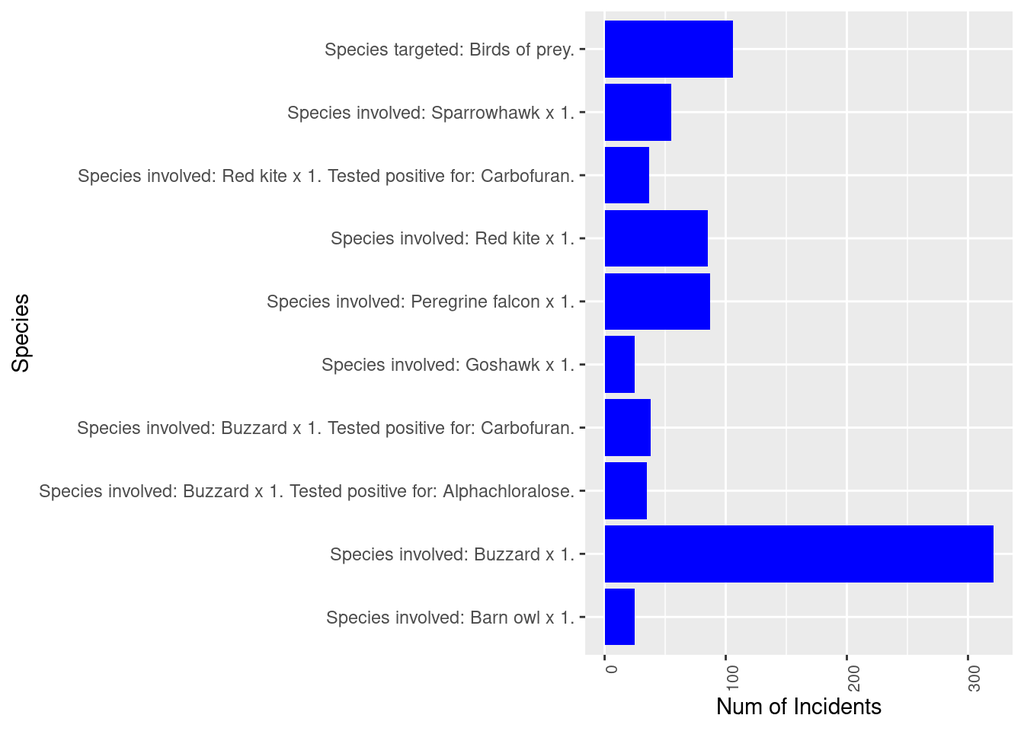

```r
ggplot(incident_species %>%
  group_by(details) %>%
  summarise(n = sum(n)) %>%
  arrange(desc(n)) %>%
  head(10),
  aes(x = details, y = n)) +
  geom_bar(stat="identity",fill = "blue" ) +
  coord_flip() +
  xlab("Species") +
  ylab("Num of Incidents") +
  theme(axis.text.x = element_text(angle = 90, hjust = 1, size = 8))
```

# Incidents by County (Top 10)

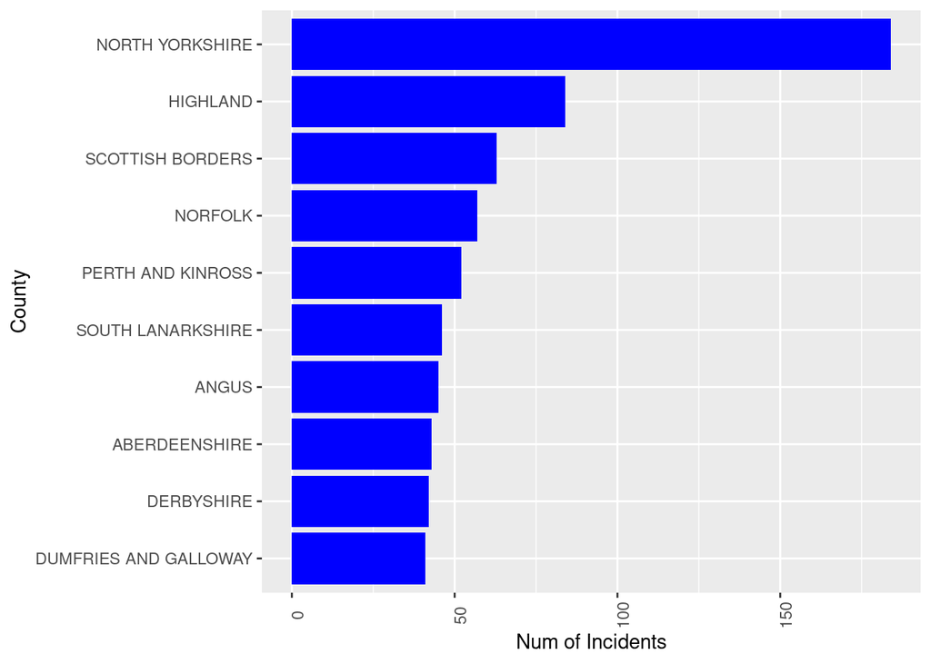

```r
ggplot(incidents_by_county %>%
  arrange(desc(n)) %>%
  head(10),
  aes(x = reorder(county, n), y = n)) +
  geom_bar(stat="identity", fill = "blue") +
  coord_flip() +
  xlab("County") +
  ylab("Num of Incidents") +
  theme(axis.text.x = element_text(angle = 90))
```